# pete

2024-02-15

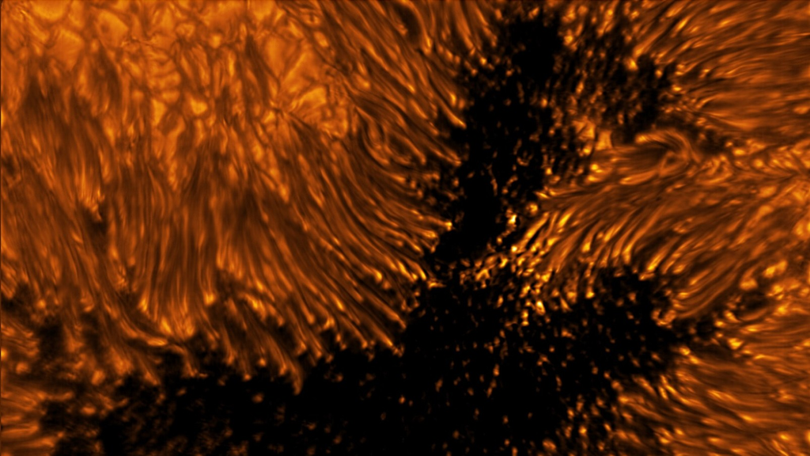

Image captured by the Daniel K. Inouye Solar Telescope.

Check out NASA’s sunspot live feed [here.](https://soho.nascom.nasa.gov/sunspots/) And the solar cycle progression from the [Space Weather Prediction Center.](https://www.swpc.noaa.gov/products/solar-cycle-progression)

## Introduction

Sunspots are massive, dark regions of strong magnetic fields on the surface of the sun. They are the result of extreme magnetic flux pushing out from within the Sun’s interior [1]. This causes these areas to cool and become denser and darker than the surrounding photosphere. These regions have the potential to trigger explosive phenomena like solar flares and coronal mass ejections. It’s crucial for scientists to model sunspot behavior as solar activity can have significant effects on Earth’s space environment, GPS navigation, satellite communications, power grids, and so much more.

### Literature

Despite the varying modeling techniques, there is one phenomenon that all researchers agree on - the sun exhibits an approximate 11 year solar cycle. The solar cycle is indicated by the frequency and intensity of visible sunspots, and have proven to be quite difficult to predict [2]. In this study, we will employ various classical time series methods in attempt to capture the implicit behavior in sunspot activity.

## Data

Our data includes 3300 (as of February 15, 2024) observations of monthly mean relative sunspot numbers (count) from 1749 to present. The data was collected by the Swiss Federal Observatory, Zurich until 1960, then the Tokyo Astronomical Observatory. The data is readily available at the Solar Influences Data Analysis Center’s (SIDC) [website](https://www.sidc.be/SILSO/datafiles). A description of the data set provided by the SIDC is given below:

- Column 1-2: Gregorian Calender Date
- Column 3: Date in fraction of year for the middle of the corresponding month
- Column 4: Monthly mean total sunspot number
- Column 5: Monthly mean standard deviation of the input sunspot numbers from individual stations.
- Column 6: Number of observations used to compute the monthly mean total sunspot number.
- Column 7: Definitive/provisional marker. A blank indicates that the value is definitive. A ’*’ symbol indicates that the monthly value is still provisional and is subject to a possible revision (Usually the last 3 to 6 months).

This report will focus on uni-variate analysis, and thus we will only use column 4, monthly mean total sunspot number.

Monthly mean sunspot data

| Year | Month | date.franction | monthly.mean | monthly.sd | monthly.obs | prov.marker |
| --- | --- | --- | --- | --- | --- | --- |
| 1749 | 2 | 1749.123 | 104.3 | -1 | -1 | 1 |
| 1749 | 3 | 1749.204 | 116.7 | -1 | -1 | 1 |
| 1749 | 4 | 1749.288 | 92.8 | -1 | -1 | 1 |
| 1749 | 5 | 1749.371 | 141.7 | -1 | -1 | 1 |
| 1749 | 6 | 1749.455 | 139.2 | -1 | -1 | 1 |

## EDA

As one does in time series modeling, we start off by simply plotting the data.

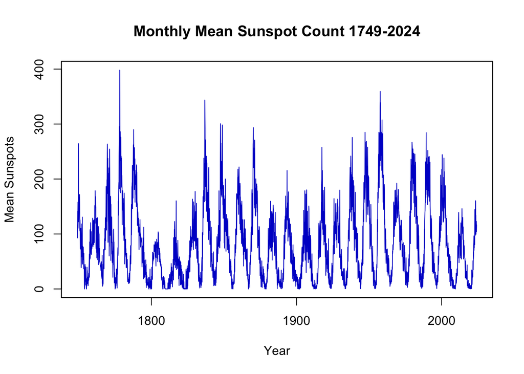

Time series plot of all mean sunspot data from sample

Plotting the sample autocorrelation will give us some insight. The sample correlation, also known as the ACF, if defined by:

$$\rho_h=\rho(y_{1:N}^*)=\frac{\gamma_h}{\gamma_0}$$

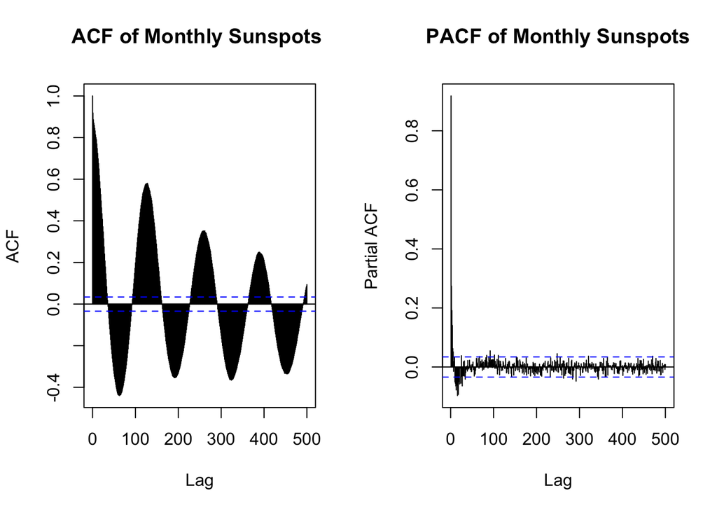

```r
#plotting ACF and PACF
par(mfrow=c(1,2))
acf(coredata(sun.data), lag.max = 500, main = "ACF of Monthly Sunspots ")
pacf(coredata(sun.data), lag.max = 500, main = "PACF of Monthly Sunspots")
```

```r
# # Slice the first 100 observations of the data
# zoomed_data <- sun.data[1:500]
#
# # Plot the sliced data
# plot.zoo(zoomed_data, xlab = "Year", ylab = "Mean Sunspots",
#          col = "mediumblue", lwd = 1)
# title("Monthly Mean Sunspot Count (First 500 Observations)")
# abline(v = index(zoomed_data)[80], col = "red", lty = 2)
# abline(v = index(zoomed_data)[208], col = "red", lty = 2)
# abline(v = index(zoomed_data)[320], col = "red", lty = 2)
# abline(v = index(zoomed_data)[425], col = "red", lty = 2)
```

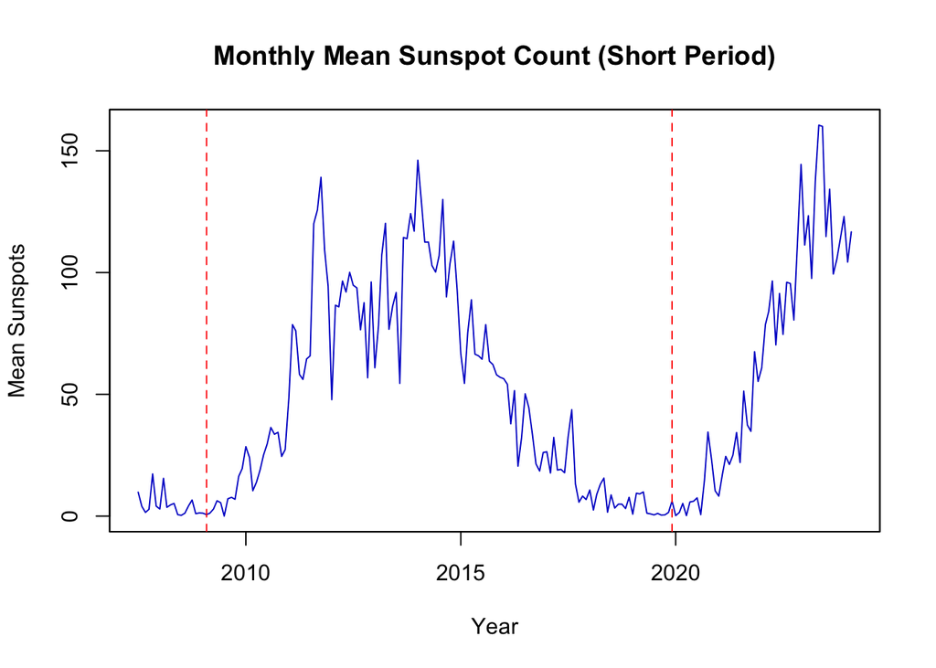

Last 200 observations of sample data

```r
# Slice the last 200 observations of the data
zoomed_data <- tail(sun.data, 200)

# Plot the sliced data
plot.zoo(zoomed_data, xlab = "Year", ylab = "Mean Sunspots",
         col = "mediumblue", lwd = 1)
title("Monthly Mean Sunspot Count (Short Period)")
abline(v = index(zoomed_data)[20], col = "red", lty = 2)
abline(v = index(zoomed_data)[150], col = "red", lty = 2)
```

Over short term periods, it may appear that there are linear trends. However, looking back at the full data, it becomes apparent that these are elements of a much broader cyclical trend. There are many successive points indicating autoregression, however the strength of the relationship changes over time with a stronger relationship occurring at the low point of the cycle. This shows ut that it’s obvious that the variance changes. Furthermore, figure 2 highlights the general concurrences of an approximate 11 year solar cycle.

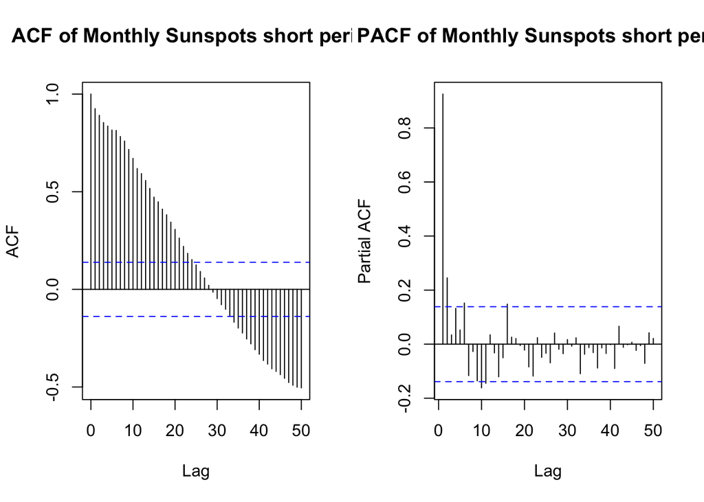

```r
#plotting ACF and PACF
par(mfrow=c(1,2))
acf(coredata(zoomed_data), lag.max = 50, main = "ACF of Monthly Sunspots short period")
pacf(coredata(zoomed_data), lag.max = 50, main = "PACF of Monthly Sunspots short period")
```

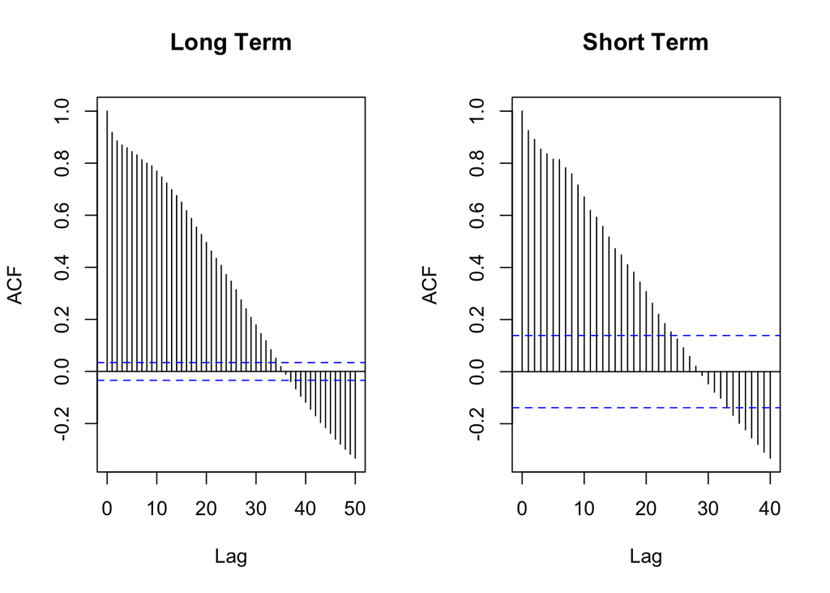

```r
# Plotting short and long term ACF to compare
par(mfrow=c(1,2))
acf(coredata(sun.data), lag.max = 50, main = "Long Term")
acf(coredata(zoomed_data), lag.max = 40, main = "Short Term")
```

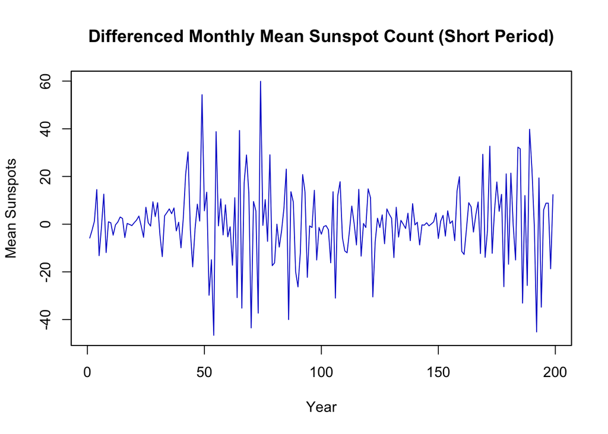

```r
annual_short <- diff(coredata(zoomed_data))

# Plot the sliced differenced data
plot.zoo(annual_short, xlab = "Year", ylab = "Mean Sunspots",
         col = "mediumblue", lwd = 1)
title("Differenced Monthly Mean Sunspot Count (Short Period)")
```

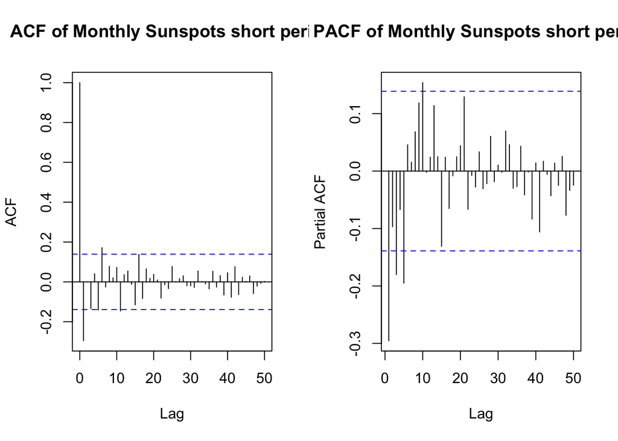

```r
#plotting ACF and PACF
par(mfrow=c(1,2))
acf(coredata(annual_short), lag.max = 50, main = "ACF of Monthly Sunspots short period")
pacf(coredata(annual_short), lag.max = 50, main = "PACF of Monthly Sunspots short period")
```

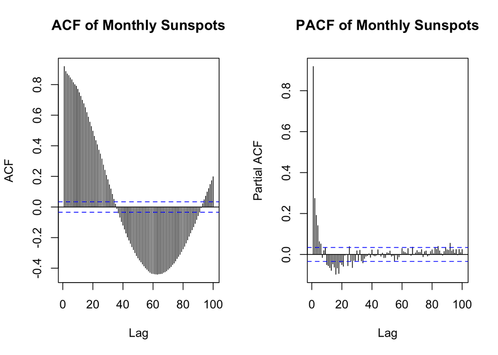

```r
#plotting ACF and PACF
par(mfrow=c(1,2))
forecast::Acf(coredata(sun.data), lag.max = 100, main = "ACF of Monthly Sunspots")
forecast::Acf(coredata(sun.data), type = "partial", lag.max = 100, main = "PACF of Monthly Sunspots")
```

### Spectral Analysis

We will use the spectral density function to identify the large frequency components of our data. The spectral density function is written as:

$$\lambda(\omega) =
\sum_{h=-\infty}^{\infty}\gamma_h e^{-2\pi i\omega h}$$

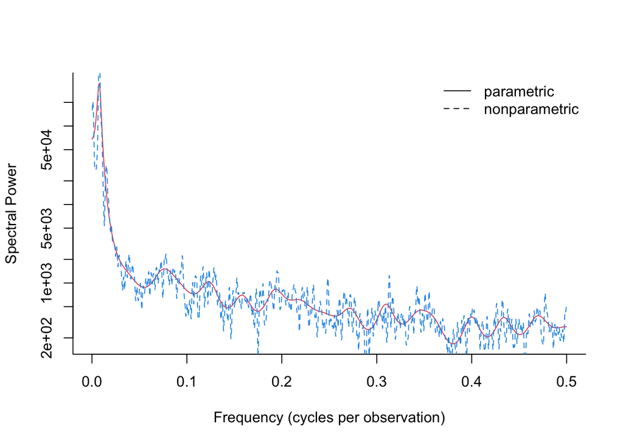

Spectral estimation using parametric and non-parametric methods.

```r
sunspot_ar <- spec.ar(coredata(sun.data), plot = FALSE) # parametric estimation based on
                                              # AR model
sunspot_np <- spectrum(coredata(sun.data), spans = c(5, 5), plot = FALSE) # nonparametric
plot(sunspot_ar$freq, sunspot_ar$spec, type = "l", log = "y",
     ylab = "Spectral Power", xlab = "Frequency (cycles per observation)",
     bty = "l", col = 2)
lines(sunspot_np$freq, sunspot_np$spec, lty = 2, col = 4)
legend("topright", c("parametric", "nonparametric"), lty = 1:2, bty = "n")
```

```r
domain_freq_ar <- sunspot_ar$freq[which.max(sunspot_ar$spec)]
domain_freq_np <- sunspot_np$freq[which.max(sunspot_np$spec)]

period_ar <- 1/(domain_freq_ar*12)
period_np <- 1/(domain_freq_np*12)

print(period_ar)
```

```
## [1] 10.39583
```

```r
print(period_np)
```

```
## [1] 10.81731
```

Both the parametric and non-parametric spectral give roughly the same max frequencies of **0.008** and **0.0077** respectively. We will use the formula, $\frac{1}{\omega\times12}$ where $\omega$ = frequency to translate the values from the **frequency domain** back to the **time domain**. Note that we multiply $\omega$ by 12 since we are dealing with monthly data. This equates out to be **10.396** years for the AR and **10.817** for the nonparametric methods. These results are consistent with the 11-year solar cycle.

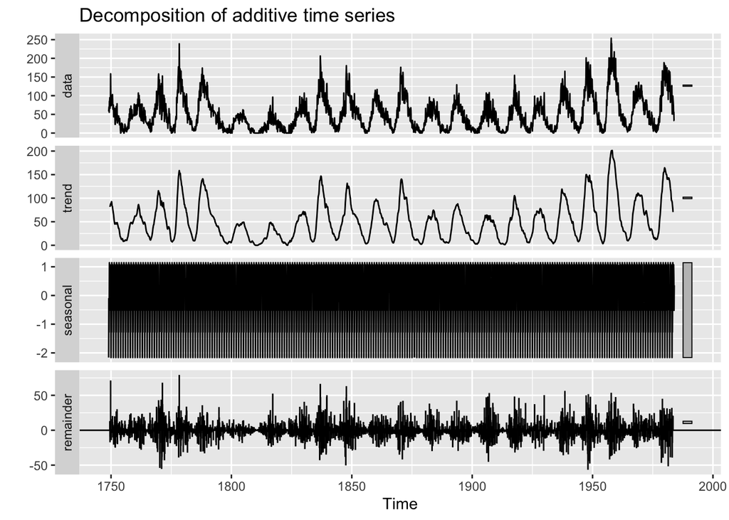

```r
autoplot(decompose(sunspots))
```

The grey bars to the right of each panel show the relative scales of the components. Each grey bar represents the same length but because the plots are on different scales, the bars vary in size.

## Model Selection

### SARIMA

The seasonal part of an AR or MA model can be discovered through the seasonal lags of the PACF and ACF.

## Future Extensions

There are numerous avenues one could take exploring this data set. It would be interesting to see how more modern machine/deep learning methods perform in comparison to classical time series approaches. The 11-year solar cycle is indeed glaring, however perhaps it’s so bright that it’s caused researchers to overlook hidden seasonal trends?

1.

Sunspots/solar cycle.

2.

Dobrijevic, D. Solar cycle: What is it and why does it matter?